# R/Rstudio基础和操作入门

# 第三节：ggplot2基础绘图

## 一、ggplot2入门

```r
#官方帮助使用文档：https://ggplot2.tidyverse.org/reference/
#安装R包
# install.packages("ggplot2")
#加载R包
 library(ggplot2)
library(tidyverse)
```

## 二、散点图

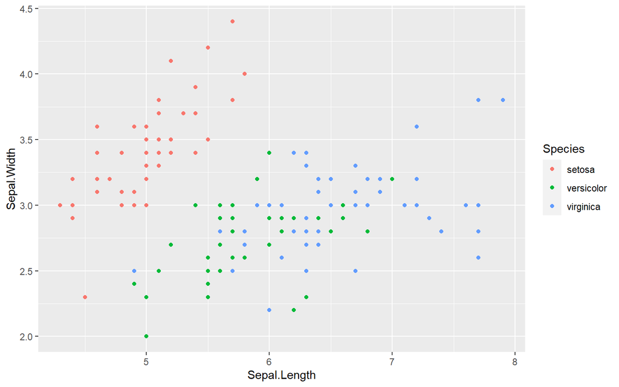

```r
    data(iris) #导入测试数据集
    ggplot(iris,aes(x=Sepal.Length,y=Sepal.Width,color=Species)) +
      geom_point()
```

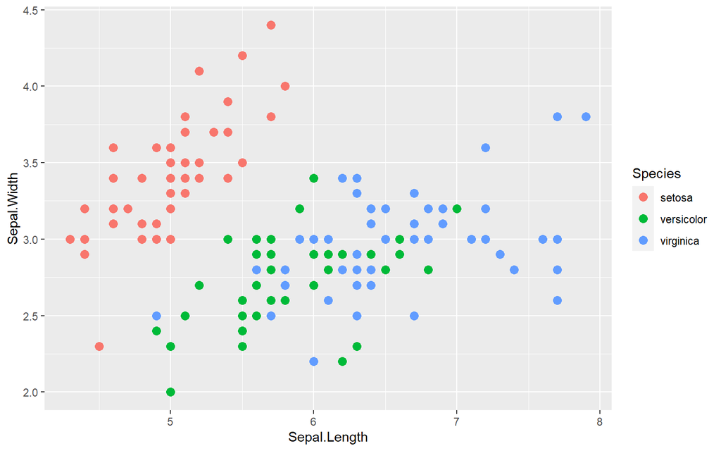

```r
    ggplot(iris,aes(x=Sepal.Length,y=Sepal.Width,color=Species)) +
      geom_point(size=3)
```

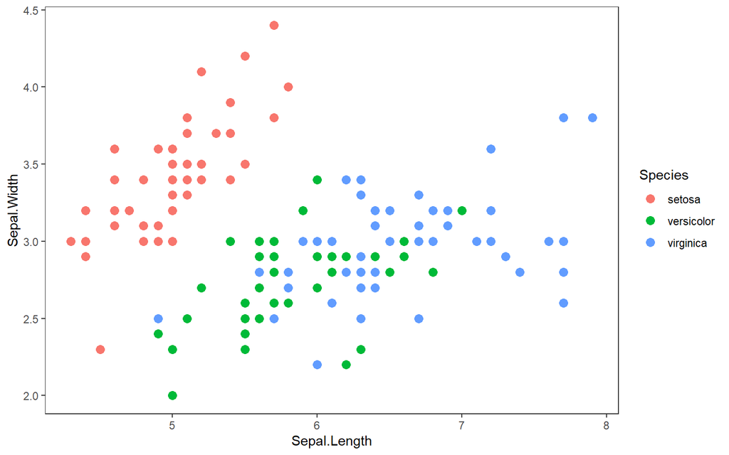

```r
    ggplot(iris,aes(x=Sepal.Length,y=Sepal.Width,color=Species)) +
      geom_point(size=3) +
      theme_bw() +
      theme(panel.grid.minor = element_blank(),panel.grid.major = element_blank())
```

## 三、箱线图

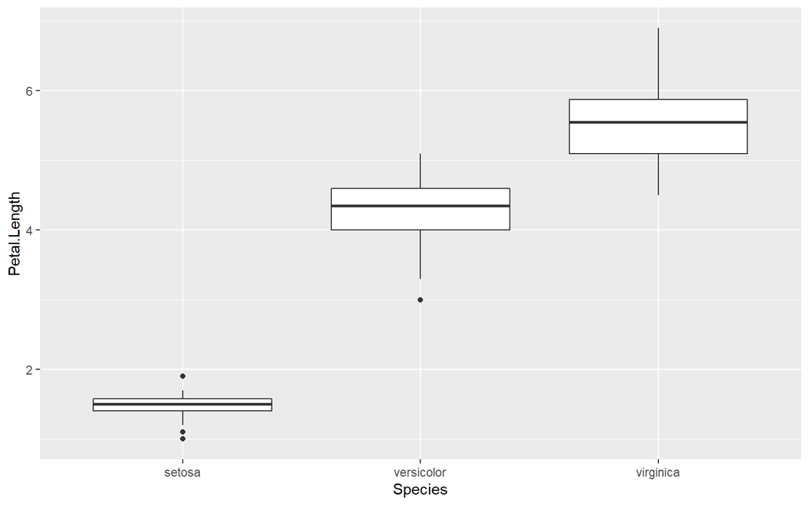

```r
p.box <- ggplot(iris,aes(x=Species,y=Petal.Length)) + geom_boxplot()
    p.box
```

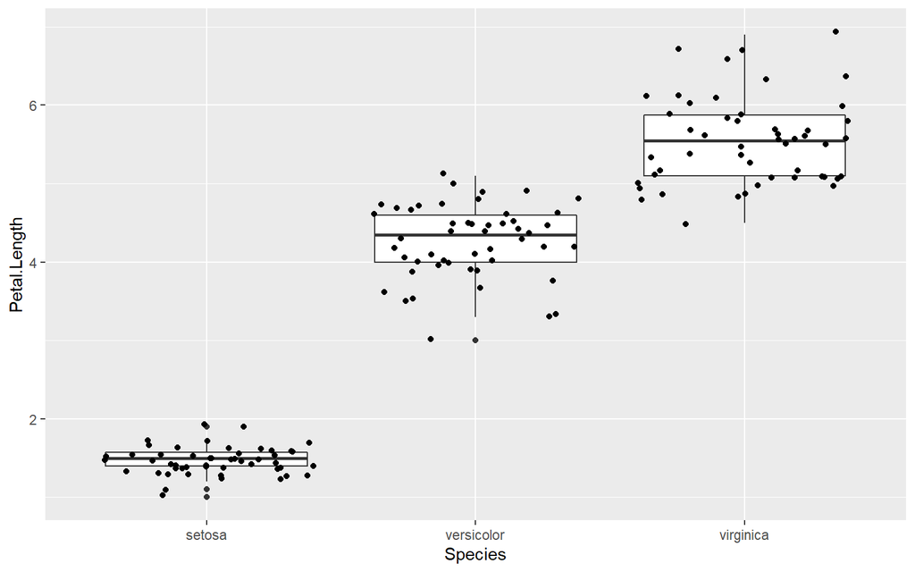

```r
    p.box.jitter <- p.box + geom_jitter(aes(x=Species, y=Petal.Length))
    p.box.jitter
```

## 四、柱状图

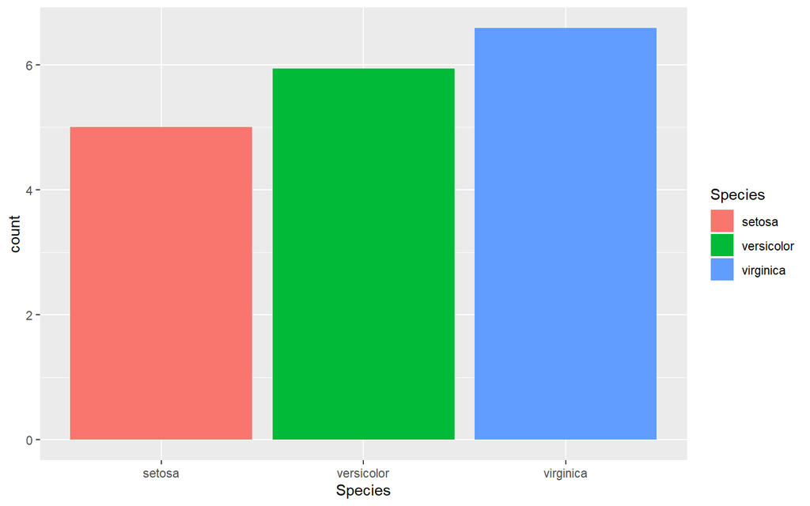

```r
    group_iris <- iris %>% group_by(Species) %>%
      dplyr::summarise(avg_sepal_length=mean(Sepal.Length))
    ggplot(group_iris,aes(x=Species, weight=avg_sepal_length, fill=Species)) + geom_bar()
```

## 五、小提琴图

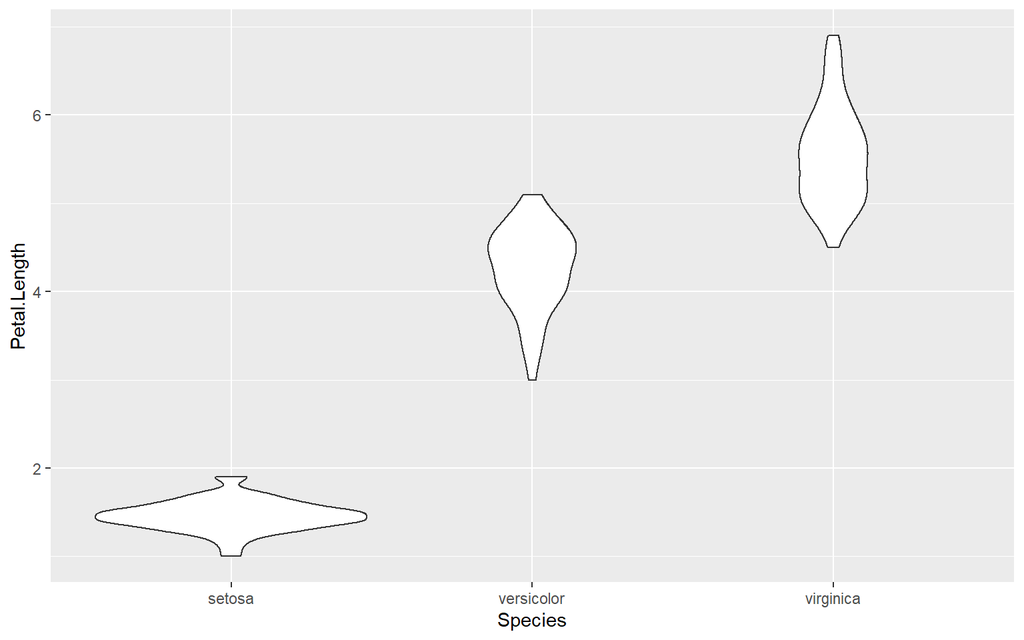

```r
    ggplot(iris, aes(x=Species, y=Petal.Length)) + geom_violin()
```

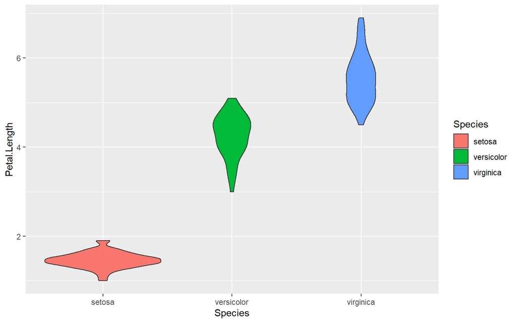

```r
    ggplot(iris, aes(x=Species, y=Petal.Length,fill=Species)) + geom_violin()
```

```r
 #   setwd("C:/Users/FengXing/Desktop")
    p <- ggplot(iris, aes(x=Species, y=Petal.Length,fill=Species)) + geom_violin()
  #  ggsave(p, file="test.jpg")
```

## 六、单细胞图谱

```r
library(Seurat)
library(SeuratData)
pbmc3k.final
```

```
## An object of class Seurat
## 13714 features across 2638 samples within 1 assay
## Active assay: RNA (13714 features, 2000 variable features)
##  2 dimensional reductions calculated: pca, umap
```

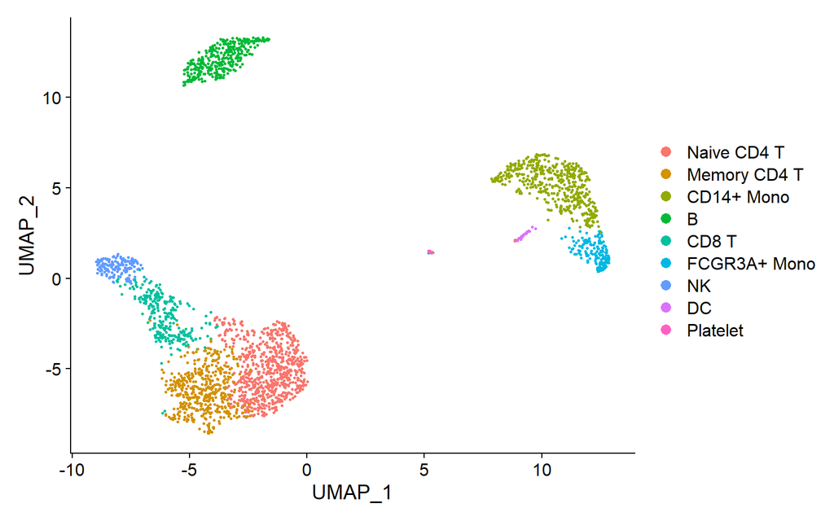

```r
library(ggplot2)
p1<- DimPlot(pbmc3k.final)

p1
```

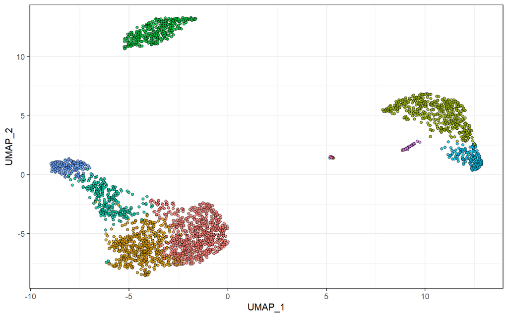

```r
p2<- ggplot(DimPlot(pbmc3k.final)$data,aes(UMAP_1        , UMAP_2   ,fill=ident)) +
  geom_point(shape=21,colour="black",stroke=0.25,alpha=0.8) +
  DimPlot(pbmc3k.final,label = T)$theme +
  theme_bw()+ NoLegend()
p2
```

## 七、细胞比例柱形图

```r
library(tidyverse)
pbmc<- pbmc3k.final
library(Seurat)
pbmc3k.final
```

```
## An object of class Seurat
## 13714 features across 2638 samples within 1 assay
## Active assay: RNA (13714 features, 2000 variable features)
##  2 dimensional reductions calculated: pca, umap
```

```r
library(ggplot2)
pbmc<-AddMetaData(pbmc,pbmc@reductions$umap@cell.embeddings,col.name = colnames(pbmc@reductions$umap@cell.embeddings))
pbmc$replicate <- sample(c("rep1", "rep2"), size = ncol(pbmc), replace = TRUE)
head(pbmc@meta.data)
```

```
##                orig.ident nCount_RNA nFeature_RNA seurat_annotations percent.mt
## AAACATACAACCAC     pbmc3k       2419          779       Memory CD4 T  3.0177759
## AAACATTGAGCTAC     pbmc3k       4903         1352                  B  3.7935958
## AAACATTGATCAGC     pbmc3k       3147         1129       Memory CD4 T  0.8897363
## AAACCGTGCTTCCG     pbmc3k       2639          960         CD14+ Mono  1.7430845
## AAACCGTGTATGCG     pbmc3k        980          521                 NK  1.2244898
## AAACGCACTGGTAC     pbmc3k       2163          781       Memory CD4 T  1.6643551
##                RNA_snn_res.0.5 seurat_clusters    UMAP_1    UMAP_2 replicate
## AAACATACAACCAC               1               1 -4.232792 -4.152139      rep1
## AAACATTGAGCTAC               3               3 -4.892886 10.985685      rep2
## AAACATTGATCAGC               1               1 -5.508639 -7.211088      rep2
## AAACCGTGCTTCCG               2               2 11.332233  3.161727      rep2
## AAACCGTGTATGCG               6               6 -7.450703  1.092022      rep1
## AAACGCACTGGTAC               1               1 -3.509504 -6.087042      rep1
```

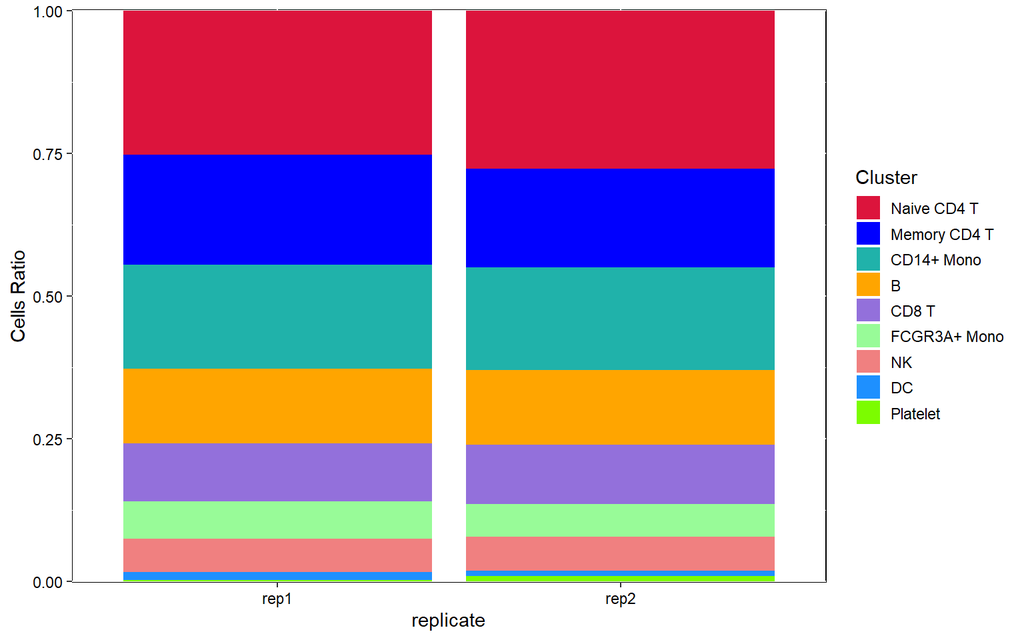

```r
as.data.frame(prop.table(table(Idents(pbmc), pbmc@meta.data[,"replicate"]), margin = 2))-> pdf -> td
allcolour=c("#DC143C","#0000FF","#20B2AA","#FFA500","#9370DB","#98FB98","#F08080","#1E90FF","#7CFC00","#FFFF00","#808000","#FF00FF","#FA8072","#7B68EE","#9400D3","#800080","#A0522D","#D2B48C","#D2691E","#87CEEB","#40E0D0","#5F9EA0","#FF1493","#0000CD","#008B8B","#FFE4B5","#8A2BE2","#228B22","#E9967A","#4682B4","#32CD32","#F0E68C","#FFFFE0","#EE82EE","#FF6347","#6A5ACD","#9932CC","#8B008B","#8B4513","#DEB887")
allcolour -> colour1
plt<- ggplot(td,aes(x=td[,2],y=td[,3],fill=td[,1]))+
  geom_bar(position = 'stack',stat="identity")+
  labs(x="replicate",y="Cells Ratio")+
  theme(panel.background=element_rect(fill='transparent', color='black'),
        legend.key=element_rect(fill='transparent', color='transparent'),axis.text = element_text(color="black"))+
  scale_y_continuous(expand=c(0.001,0.001))+
  scale_fill_manual(values=colour1)+
  guides(fill = guide_legend(keywidth = 1, keyheight = 1,ncol=1,title = 'Cluster'))
plt
```

## 八、细胞比例桑基图

桑基图（Sankey diagram），即桑基能量分流图，也叫桑基能量平衡图。它是一种特定类型的流程图，图中延伸的分支的宽度对应数据流量的大小，比较适用于用户流量等数据的可视化分析。因1898年Matthew Henry Phineas Riall Sankey绘制的“蒸汽机的能源效率图”而闻名，此后便以其名字命名为“桑基图”。

```r
library(Seurat)
library(dplyr)
library(tidyverse)
library(SeuratData)
pbmc3k.final
```

```
## An object of class Seurat
## 13714 features across 2638 samples within 1 assay
## Active assay: RNA (13714 features, 2000 variable features)
##  2 dimensional reductions calculated: pca, umap
```

```r
pbmc_small <- pbmc3k.final
pbmc_small <- FindClusters(pbmc_small,resolution = 0.4)
```

```
## Modularity Optimizer version 1.3.0 by Ludo Waltman and Nees Jan van Eck
##
## Number of nodes: 2638
## Number of edges: 96033
##
## Running Louvain algorithm...
## Maximum modularity in 10 random starts: 0.8884
## Number of communities: 9
## Elapsed time: 0 seconds
```

```r
pbmc_small <- FindClusters(pbmc_small,resolution = 0.6)
```

```
## Modularity Optimizer version 1.3.0 by Ludo Waltman and Nees Jan van Eck
##
## Number of nodes: 2638
## Number of edges: 96033
##
## Running Louvain algorithm...
## Maximum modularity in 10 random starts: 0.8567
## Number of communities: 10
## Elapsed time: 0 seconds
```

```r
pbmc_small <- FindClusters(pbmc_small,resolution = 0.8)
```

```
## Modularity Optimizer version 1.3.0 by Ludo Waltman and Nees Jan van Eck
##
## Number of nodes: 2638
## Number of edges: 96033
##
## Running Louvain algorithm...
## Maximum modularity in 10 random starts: 0.8288
## Number of communities: 11
## Elapsed time: 0 seconds
```

```r
pbmc_small <- FindClusters(pbmc_small,resolution = 1)
```

```
## Modularity Optimizer version 1.3.0 by Ludo Waltman and Nees Jan van Eck
##
## Number of nodes: 2638
## Number of edges: 96033
##
## Running Louvain algorithm...
## Maximum modularity in 10 random starts: 0.8033
## Number of communities: 11
## Elapsed time: 0 seconds
```

```r
pbmc_small <- FindClusters(pbmc_small,resolution = 1.2)
```

```
## Modularity Optimizer version 1.3.0 by Ludo Waltman and Nees Jan van Eck
##
## Number of nodes: 2638
## Number of edges: 96033
##
## Running Louvain algorithm...
## Maximum modularity in 10 random starts: 0.7790
## Number of communities: 11
## Elapsed time: 0 seconds
```

```r
pbmc_small <- FindClusters(pbmc_small,resolution = 1.4)
```

```
## Modularity Optimizer version 1.3.0 by Ludo Waltman and Nees Jan van Eck
##
## Number of nodes: 2638
## Number of edges: 96033
##
## Running Louvain algorithm...
## Maximum modularity in 10 random starts: 0.7565
## Number of communities: 13
## Elapsed time: 0 seconds
```

```r
pbmc_small <- FindClusters(pbmc_small,resolution = 1.6)
```

```
## Modularity Optimizer version 1.3.0 by Ludo Waltman and Nees Jan van Eck
##
## Number of nodes: 2638
## Number of edges: 96033
##
## Running Louvain algorithm...
## Maximum modularity in 10 random starts: 0.7354
## Number of communities: 14
## Elapsed time: 0 seconds
```

```r
head(pbmc_small@meta.data)
```

```
##                orig.ident nCount_RNA nFeature_RNA seurat_annotations percent.mt
## AAACATACAACCAC     pbmc3k       2419          779       Memory CD4 T  3.0177759
## AAACATTGAGCTAC     pbmc3k       4903         1352                  B  3.7935958
## AAACATTGATCAGC     pbmc3k       3147         1129       Memory CD4 T  0.8897363
## AAACCGTGCTTCCG     pbmc3k       2639          960         CD14+ Mono  1.7430845
## AAACCGTGTATGCG     pbmc3k        980          521                 NK  1.2244898
## AAACGCACTGGTAC     pbmc3k       2163          781       Memory CD4 T  1.6643551
##                RNA_snn_res.0.5 seurat_clusters RNA_snn_res.0.4 RNA_snn_res.0.6
## AAACATACAACCAC               1               9               2               1
## AAACATTGAGCTAC               3               2               3               3
## AAACATTGATCAGC               1               1               2               1
## AAACCGTGCTTCCG               2               4               1               2
## AAACCGTGTATGCG               6               8               6               6
## AAACGCACTGGTAC               1               1               2               1
##                RNA_snn_res.0.8 RNA_snn_res.1 RNA_snn_res.1.2 RNA_snn_res.1.4
## AAACATACAACCAC               1             1               5               8
## AAACATTGAGCTAC               2             2               2               2
## AAACATTGATCAGC               1             1               1               0
## AAACCGTGCTTCCG               4             4               4               5
## AAACCGTGTATGCG               7             7               8               9
## AAACGCACTGGTAC               1             1               1               0
##                RNA_snn_res.1.6
## AAACATACAACCAC               9
## AAACATTGAGCTAC               2
## AAACATTGATCAGC               1
## AAACCGTGCTTCCG               4
## AAACCGTGTATGCG               8
## AAACGCACTGGTAC               1
```

```r
table(pbmc_small@meta.data$RNA_snn_res.1.6)
```

```
##
##   0   1   2   3   4   5   6   7   8   9  10  11  12  13
## 355 353 344 273 255 225 212 162 145 142  97  32  29  14
```

```r
library(Seurat)
pbmc_small <- FindClusters(
  object = pbmc_small,
  resolution = c(seq(.4,1.6,.2))
)
```

[output not shown]

[output cut: 8 more lines]

```
## Number of edges: 96033
##
## Running Louvain algorithm...
## Maximum modularity in 10 random starts: 0.7565
## Number of communities: 13
## Elapsed time: 0 seconds
## Modularity Optimizer version 1.3.0 by Ludo Waltman and Nees Jan van Eck
##
## Number of nodes: 2638
## Number of edges: 96033
##
## Running Louvain algorithm...
## Maximum modularity in 10 random starts: 0.7354
## Number of communities: 14
## Elapsed time: 0 seconds
```

```r
library(ggalluvial)
library(tidyverse)

head(pbmc_small@meta.data)
```

```
##                orig.ident nCount_RNA nFeature_RNA seurat_annotations percent.mt
## AAACATACAACCAC     pbmc3k       2419          779       Memory CD4 T  3.0177759
## AAACATTGAGCTAC     pbmc3k       4903         1352                  B  3.7935958
## AAACATTGATCAGC     pbmc3k       3147         1129       Memory CD4 T  0.8897363
## AAACCGTGCTTCCG     pbmc3k       2639          960         CD14+ Mono  1.7430845
## AAACCGTGTATGCG     pbmc3k        980          521                 NK  1.2244898
## AAACGCACTGGTAC     pbmc3k       2163          781       Memory CD4 T  1.6643551
##                RNA_snn_res.0.5 seurat_clusters RNA_snn_res.0.4 RNA_snn_res.0.6
## AAACATACAACCAC               1               9               2               1
## AAACATTGAGCTAC               3               2               3               3
## AAACATTGATCAGC               1               1               2               1
## AAACCGTGCTTCCG               2               4               1               2
## AAACCGTGTATGCG               6               8               6               6
## AAACGCACTGGTAC               1               1               2               1
##                RNA_snn_res.0.8 RNA_snn_res.1 RNA_snn_res.1.2 RNA_snn_res.1.4
## AAACATACAACCAC               1             1               5               8
## AAACATTGAGCTAC               2             2               2               2
## AAACATTGATCAGC               1             1               1               0
## AAACCGTGCTTCCG               4             4               4               5
## AAACCGTGTATGCG               7             7               8               9
## AAACGCACTGGTAC               1             1               1               0
##                RNA_snn_res.1.6
## AAACATACAACCAC               9
## AAACATTGAGCTAC               2
## AAACATTGATCAGC               1
## AAACCGTGCTTCCG               4
## AAACCGTGTATGCG               8
## AAACGCACTGGTAC               1
```

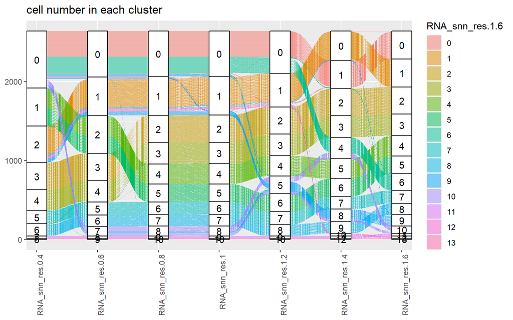

```r
ggplot(data = pbmc_small@meta.data,
       aes(axis1 = RNA_snn_res.0.4, axis2 = RNA_snn_res.0.6,axis3 = RNA_snn_res.0.8,axis4 = RNA_snn_res.1,
           axis5 = RNA_snn_res.1.2,axis6 = RNA_snn_res.1.4,axis7 = RNA_snn_res.1.6)) +
  scale_x_discrete(limits = c(paste0("RNA_snn_res.",seq(.4,1.6,.2))), expand = c(.01, .05)) +
  geom_alluvium(aes(fill = RNA_snn_res.1.6)) +
  geom_stratum() + geom_text(stat = "stratum", infer.label = TRUE) +
  #coord_polar()+
  theme(axis.text.x = element_text(angle = 90, hjust = 1))+
  ggtitle("cell number in each cluster")
```